# An Introduction to FastqCleaner

Leandro Roser, Fernán Agüero and Daniel Sánchez

IIB-INTECH - UNSAM

learoser@gmail.com

Feb 15, 2020

#### Abstract

*FastqCleaner* is an interactive application for both quality control and pre-processing of FASTQ files. The interface, based on a Bioconductor back-end, provides diagnostic information for the input and output data and a series of filtering and trimming operations in an interactive framework.

# 1 Launching the application

The interactive application can be launched in R with the following command:

```r
library('FastqCleaner')
launch_fqc()
```

As an alternative method, an RStudio addin (RStudio version 0.99.878 or higher required) installed with the package can be found in the Addins menu (Figure 1). This button allows the direct launch of the application with a single click.

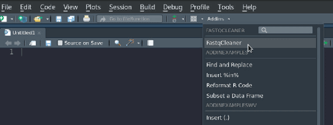

**Figure 1**: addin of the app in RStudio (RStudio version >= 0.99.878 required)

# 2 Description of the application

The application contains three main panels, as described below.

## 2.1 First panel

The first panel includes two elements: a dashboard for selection of trimming and filtering operations, and a menu for selection of the input file/s (Fig. 2).

[figure not shown]

**Figure 2**: Panel 1, with each compontent indicated with a number. See explanation for each element below

### 2.1.2 Loading files

The “file selection menu” (Fig. 2, elements 9 to 17) contains options to handle the input file (type of file, file selection), buttons to run, clear and reset the aplication, and the “advanced” submenu:

9. **Single-end reads / paired-end reads**: type of input files
10. **“FILE” button**: to select an input file
11. **“RUN!” button**: to run the program
12. **Output format**: to select whether the output file should be compressed (.gz) or not
13. **“CLEAR” button**: to clear the configuration of the operations menu that have been selected in the first panel, but keeping the input file(s)
14. **“RESET” button**: to restart the application, removing the input file(s) and the selected configurations
15. **Selection notificator**: information of the path of the selected file/s
16. **Encoding notificator**: information of the input file/s encoding
17. **Advanced options button**: to select a custom encoding and set the number of reads included in each chunk for processing, as described below

### 2.1.3 Advanced options

The “advanced options submenu” (Fig. 3) allows to customize some fine aspects of the trimming and filtering process:

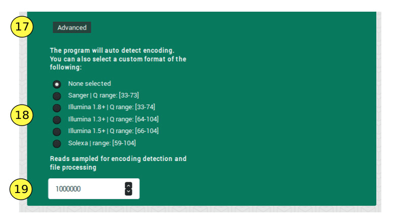

**Figure 3**: Advanced options submenu

18. **Encoding menu**: in addition to the default approach used by the program (auto-detection of file encoding), users can select a standard encoding from a list
19. **Chunk size**: the program takes this number of reads at random from the file (default: 1000000), for encoding detection

## 2.2 Second panel

The second panel (“file operations” panel, Fig. 4) shows the operations that were sucessfuly performed on the input file after running the program.

[figure not shown]

**Figure 4**: File operations panel, with its elements

The panel contains the following elements:

20. **Files location**: location of input and output files
21. **Operations performed**: operations perfomed on the input file. Each individual display indicates the number of reads that passed the corresponding filter

## 2.3 Third panel

The third panel ( “live results” panel, Fig. 5) shows interactive diagnostics plots for both input and output files. The program takes a random sample of reads for construction of the plots (default: 10000 reads).

[figure not shown]

**Figure 5**: Live results panel

The panel includes the following options in the menu located on the left:

22. **Sample size**: the sample size used for construction of the plots. Default: 10000 reads
23. **Input / output**: show diagnostics plots for input or output files?
24. **Diagnostics plots**: the plot to be shown, that can be one of the following:
    - *Per cycle quality*: quality plots across reads for each cycle (i.e., sequence position)
    - *Per cycle mean quality*: average quality across reads per base, for each cycle (i.e., sequence position)
    - *Mean quality distribution*: Quality distribution, using for the construction of the histogram the mean quality of each read
    - *% reads with Phred scores > threshold*: % of reads with all the quality values > threshold
    - *Per cycle base proportion*: Proportion of each base (average across reads) in each cycle. It also shows the proporion of N’s
    - *CG content*: % CG and % AT (average across reads) for each cycle
    - *CG content distribution over all reads*: histogram for % reads with a given % CG
    - *Read length distribution*: % reads vs read length (bp)
    - *Read ocurrence distribution*: % reads that ocurr at different frequencies values in the file. The plot also includes a table
    - *Relative k-mer diversity*: unique k-mers / all posible kmers for each cycle
25. **Select k-mer size**: k-mer size for the k-mers frequency plot
26. **Top sequences in duplication level analysis**: a list of duplicated sequences, ordered from high to low duplication level, can be desplegated from the “read ocurrence distribution” plot. The number selected here indicates how many sequences should be shown. Note that the frequency of reads are relative to the sample size selected (i.e., fold-times in relation to those reads present only once in the sample)
27. **Plot panel**

# 3 A worked example: FASTQ processing in a nutshell

A sample FASTQ (gz-compressed) file ‘example.fastq.gz’ can be downloaded with the following command in R:

```r
download.file("https://goo.gl/hb4Kr9", "example_fastq.gz")
```

A direct download is provided in [this link](https://goo.gl/hb4Kr9) .

A tipical *FastqCleaner* workflow starts with the input file/s upload (Fig. 6).

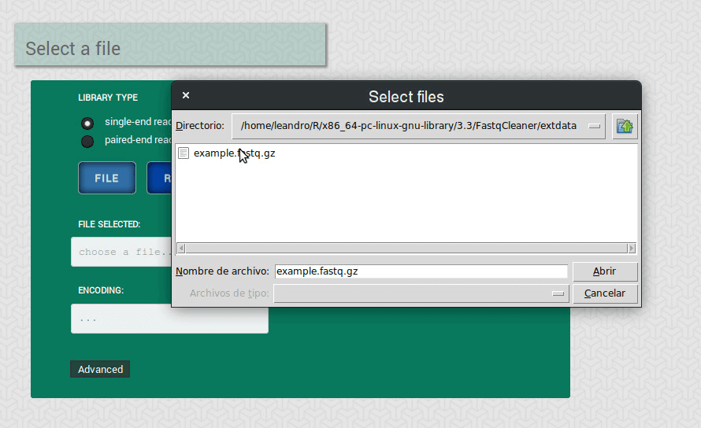

**Figure 6**: File input menu. The example shows a single-end reads case (sample file ‘example.fastq.gz’). For paired-end reads, the selection of the corresponding library type generates an additional button to upload the second file.

The file encoding is automatically detected by the program, but it can also be manually specified in the advanced submenu (Fig. 7). This menu also offers an option to customize the chunk size used for processing.

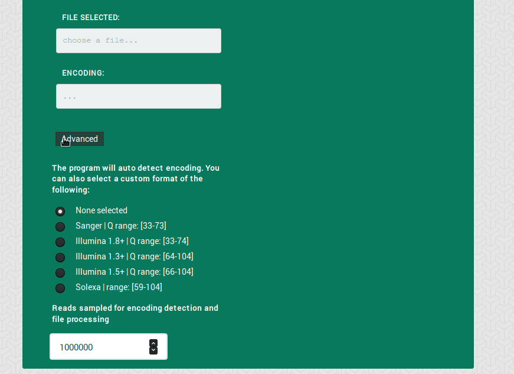

**Figure 7**: Advanced submanu

Next, the operations to be performed on the input file are selected from the operations menu (Fig. 8).

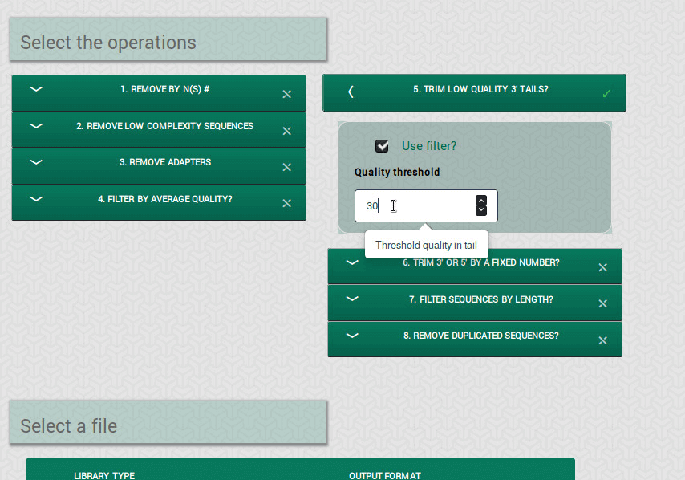

**Figure 8**: Selection of operations. A dialog box shows the input expected for the program. To use a filter, the “Use filter?” checkbox must be checked. A filter in use is indicated with a checkmark in the filter box

The program then starts to run after pressing the “RUN!” button (Fig. 9).

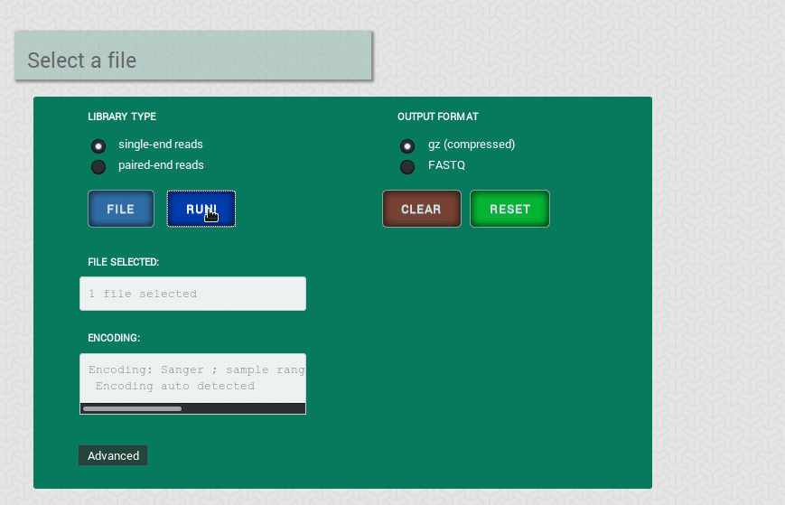

**Figure 9**: “RUN!” button action

Post-processing results are shown in the second panel (Fig. 10).

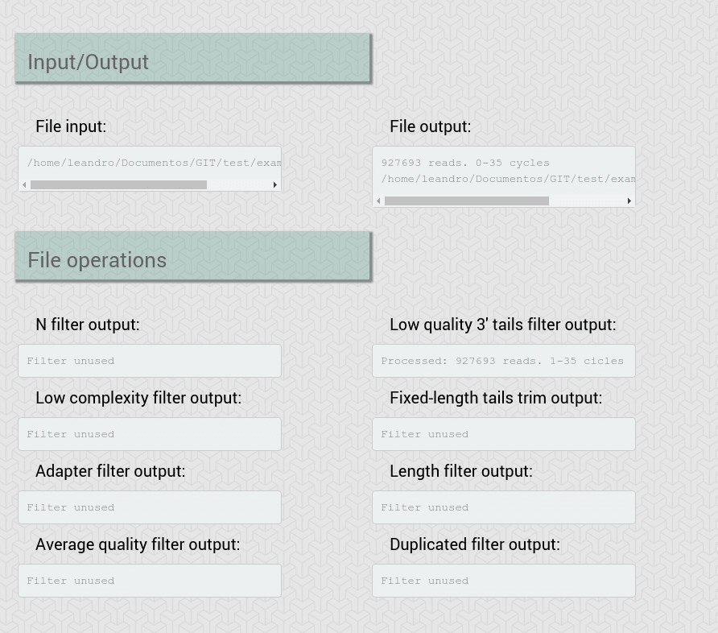

**Figure 10**: Second panel of the app, showing the operations performed and the paths of the input and output files

The type of plot to be displayed and the options for the construction of the plot are available in the third panel (Fig. 11). This panel also show the selected plot/s.

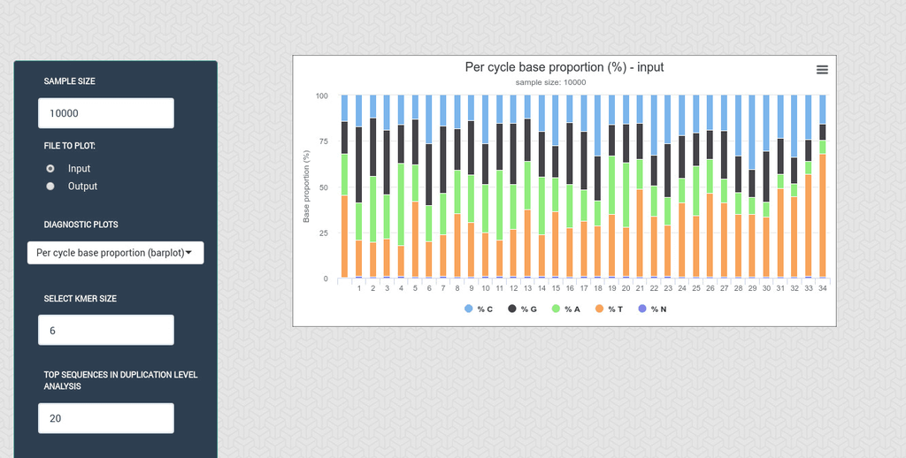

Additional help can be found in the “help” button located at the top-right of the app (Fig. 12).

[figure not shown]

**Figure 12**: help button. A webpage with information will be open

# 4 Advanced use of the package

*FastqCleaner* separates the interface from the implementation. In consequence, the processing functions of the package can be used as standard functions from the command line. Most of the functions make intensive use of *Biostrings* and *ShortRead*. Trimming and filtering is performed on ShortReadQ objects. A complete documentation for the functions is available in this link

The functions included in the package are described in the following section.